# SI 618 WN 2018 - Homework 3: Pandas Data Analysis

# Time to learn something new

We learned about pivot, stack, unstack, and pivot_table earlier in the course. What we didn't learn was how to "unpivot" data. In pandas, you use the "melt" function to do that. You will need to use melt() for the next step.

The Student Record data set has three columns to represent the departments that correspond to the first three majors that each student has declared. The order of those isn't important. Not all students have three majors, so some of those fields will be blank.

We want to get a list of all the departments that each student is in, for every row in the joined table (i.e. the one you generated earlier that joins Student Course and Student Record). So if a student was in a major that belonged to the Psychology Department and another one that belonged to "English Language & Literature Dept", and that student had taken STATS250 and ECON101, there would be 4 rows for that student in the resulting table: one row that indicated the student was in the Psychology Department and had taken STATS250, a second one that indicated the student was in English and had taken STATS250, a third one that indicated they were in Psychology and had taken ECON101, and a fourth one indicating they were in English and had taken ECON 101. That's what we mean by "unpivoting" (or, in our case, melt()ing).

Here's what the syntax for the melt() is going to look like:

```
joined.melt(id_vars='ANONID',
                     value_vars=['MAJOR1_DEPT','MAJOR2_DEPT','MAJOR3_DEPT'],
                     value_name='DEPT',
                     var_name='DEPT_NBR')
```

Copy that below, and assign it to `melted`

The following code assumes the joined DataFrame you generated above is called "joined"

```python
joined.head()
```

|  | ANONID | SUBJECT | CATALOG_NBR | GRD_PTS_PER_UNIT | GPAO | DIV | ANON_INSTR_ID | TERM | MAJOR3_DESCR | MAJOR2_DESCR | ... | SEX | STDNT_GROUP1 | STDNT_GROUP2 | MAJOR1_DEPT | MAJOR2_DEPT | MAJOR3_DEPT | ADMIT_TERM | MAJOR1_TERM | MAJOR2_TERM | MAJOR3_TERM |
| --- | --- | --- | --- | --- | --- | --- | --- | --- | --- | --- | --- | --- | --- | --- | --- | --- | --- | --- | --- | --- | --- |
| 0 | 26 | ACC | 272 | 2.0 | 3.343636 | P | 2920 | 79 | NaN | NaN | ... | F | NaN | NaN | College of Literature, Science, and the Arts | NaN | NaN | 73.0 | 89.0 | NaN | NaN |
| 1 | 114 | ACC | 272 | 2.0 | 2.817857 | P | 2920 | 83 | NaN | NaN | ... | F | NaN | NaN | Economics Department | NaN | NaN | 78.0 | 93.0 | NaN | NaN |
| 2 | 121 | ACC | 272 | 4.0 | 4.000000 | P | 201 | 111 | NaN | NaN | ... | F | NaN | NaN | School of Business Administration | NaN | NaN | 106.0 | 119.0 | NaN | NaN |
| 3 | 125 | ACC | 272 | 1.3 | 3.639063 | P | 3360 | 84 | NaN | NaN | ... | F | NaN | NaN | Psychology Department | NaN | NaN | 78.0 | 94.0 | NaN | NaN |
| 4 | 180 | ACC | 272 | 3.0 | 3.846154 | P | 2920 | 107 | NaN | NaN | ... | M | NaN | NaN | School of Business Administration | NaN | NaN | 102.0 | 115.0 | NaN | NaN |

5 rows × 30 columns

```python
melted = joined.melt(id_vars='ANONID',
                     value_vars=['MAJOR1_DEPT','MAJOR2_DEPT','MAJOR3_DEPT'],
                     value_name='DEPT',
                     var_name='DEPT_NBR')
```

Now take a look at melted

```python
melted.head()
```

|  | ANONID | DEPT_NBR | DEPT |
| --- | --- | --- | --- |
| 0 | 26 | MAJOR1_DEPT | College of Literature, Science, and the Arts |
| 1 | 114 | MAJOR1_DEPT | Economics Department |
| 2 | 121 | MAJOR1_DEPT | School of Business Administration |
| 3 | 125 | MAJOR1_DEPT | Psychology Department |
| 4 | 180 | MAJOR1_DEPT | School of Business Administration |

We don't really care about the DEPT_NBR column, but it's not causing problems so we can just leave it there.

Next, we want to drop the NaN values (using .dropna()), and then merge it with the "joined" dataframe you generated earlier.

Finally, drop all duplicate rows (.drop_duplicates()).

```python
melted = melted.dropna()

joined_filtered = joined_filtered[(joined_filtered['COURSE'] == 'PSYCH360') | (joined_filtered['COURSE'] == 'STATS250')]

joined_table = pd.merge(joined_filtered, melted, on='ANONID', how='inner')

joined_table = joined_table.drop_duplicates()

joined_table.drop_duplicates(inplace=True)
```

## Q10: Do students in majors from the Psychology Department do better in PSYCH360 than students who are not in Psychology Department majors?

**Use the resulting table to create a plot to visually investigate the differences of students' GRD_PTS_PER_UNIT in PSYCH360, comparing the GRD_PTS_PER_UNIT for students in Psychology Department majors vs. those who were not in Psychology Department majors. Based on your plots, answer the question.**

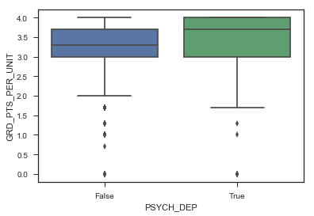

```python
# Insert your code here
# Hint: you may want to try reducing the table size first by filtering and selecting fields;
# Otherwise, it may take awhile to run your code
psy = joined_table[joined_table.COURSE == 'PSYCH360'].copy()
psy['PSYCH_DEP'] = psy.DEPT == 'Psychology Department'
sns.boxplot(x='PSYCH_DEP',
            y='GRD_PTS_PER_UNIT',
            data=psy)
print('')
```

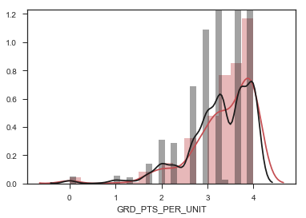

```python
sns.distplot(psy[psy.DEPT == 'Psychology Department'].GRD_PTS_PER_UNIT, color='r')
sns.distplot(psy[psy.DEPT != 'Psychology Department'].GRD_PTS_PER_UNIT, color='k')
```

#### Q10 Answer:

Finally, we are going to use the multiplePlots() function from our in-class lab to investigate the distribution of GPAO of students in STATS250 who are in majors from the Psychology Department, split by sex.

You'll need to generate two grids (one for males and one for females), each containing four plots (a histogram of the distribution, a run sequence, a lag plot, and a Q-Q plot) for the GPAO variable. Select only students who are in majors from the Psychology Department who are taking STATS250.

## Q11: Do the GPAO scores for males and females taking STATS250 who are in majors from the Psychology Department appear to be normally distributed? Explain why or why not.

```python
# Copy the multiplePlots function here.
def multiplePlots( series ):

    fig, axs = plt.subplots(2,2)
    plt.tight_layout(pad=0.4, w_pad=4, h_pad=1.0)

    # Histogram
    sns.distplot(series, ax=axs[0,0])

    # Lag plot
    lag = series.copy()
    lag = np.array(lag[:-1])
    current = series[1:]
    ax = sns.regplot(current,lag,fit_reg=False, ax=axs[0,1])
    ax.set_ylabel("y_i-1")
    ax.set_xlabel("y_i")

    # QQ plot
    qntls, xr = stats.probplot(series, fit=False)
    sns.regplot(xr,qntls, ax=axs[1,0])

    # Run sequence
    ax = sns.regplot(np.arange(len(series)),series, ax=axs[1,1])
    ax.set_ylabel("val")
    ax.set_xlabel("i")
```

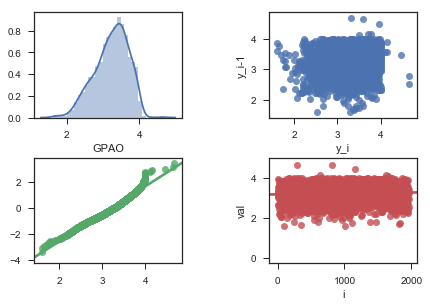

```python
# Filter the data and call the multiplePlots function here.
multiplePlots(joined_table[(joined_table.DEPT == 'Psychology Department')&(joined_table.COURSE == 'STATS250')].GPAO)
```

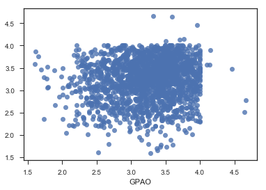

```python
alt = joined_table[(joined_table.DEPT == 'Psychology Department')&(joined_table.COURSE == 'STATS250')].GPAO
lag = alt.copy()
lag = np.array(lag[:-1])
current = joined_table[(joined_table.DEPT == 'Psychology Department')&(joined_table.COURSE == 'STATS250')].GPAO[1:]
ax = sns.regplot(current,lag,fit_reg=False)
```

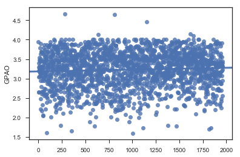

```python
bx = sns.regplot(np.arange(len(alt)),alt)
```

#### Q11 Answer:

Based on provided plots, GPAO scores for STATS250 students are not distributed normally. Histogram and QQ plot point to left-skewed distribution for GPAO scores for STATS250 students from the Psychology Department, indicating non-normality. Lag plot also indicates this, where there is a high density of data points in the 3.5-4.0 range compared to other data points.

## Q12: Create a pairplot of 'GRD_PTS_PER_UNIT', 'HSGPA', 'LAST_SATI_VERB_SCORE', and 'LAST_SATI_MATH_SCORE'. What is your conclusion from the result?

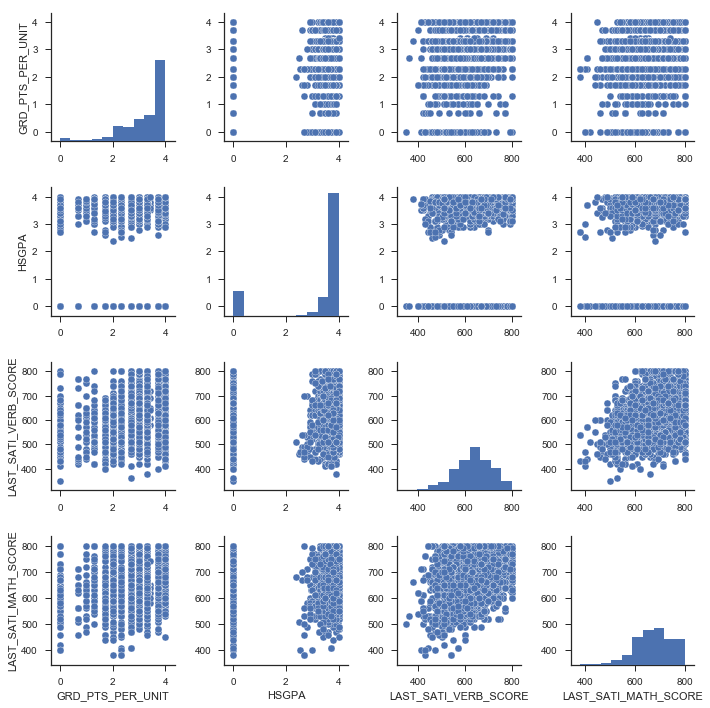

```python
# Show your code here
sns.pairplot(joined_table[['GRD_PTS_PER_UNIT', 'HSGPA', 'LAST_SATI_VERB_SCORE', 'LAST_SATI_MATH_SCORE']].dropna())
```

#### Q12 Answer:

Based on the pairplot above, it seems that there is no relationship between entrance exam scores (SATI scores for Math and Verbal) and grades received in courses. The relationship of High School GPA and all other factors also do not show correlation, probably due to the sheer density of grades near the value 4, making other factors not as predictive.

# End of Homework 3